# Qualitative Activity Recognition by MLalgorithms

RG

Mon Aug 24 00:23:18 2015

# Overview

Person activity monitoring become very popular due to different tracking devices that appeared on the market such as belts, bands and smartphones. This report explains how some of the most popular ML algorithms can be used for quantifing how well people perform dumbbell biceps curl.

# Introduction

# Getting and cleaning the data

The data can be downloaded and loaded with the following commands:

```r
if(!is.element("data",dir())){
  dir.create("./data")
}

if(!is.element("pml-training.csv",dir("./data"))){

  # download data
  trainURL<-"https://d396qusza40orc.cloudfront.net/predmachlearn/pml-training.csv"
  testURL<-"https://d396qusza40orc.cloudfront.net/predmachlearn/pml-testing.csv"
  download.file(trainURL, destfile = "./data/pml-training.csv")
  download.file(testURL, destfile = "./data/pml-testing.csv")
  dateDownloaded <- date()
}

# read data
train <- read.csv("./data/pml-training.csv", header = TRUE, sep = ",", na.strings=c("NA", "", "#DIV/0!"))
test <- read.csv("./data/pml-testing.csv", header = TRUE, sep = ",", na.strings=c("NA", "", "#DIV/0!"))
```

```r
#delete metadata
train <- train[,8:160]
test <- test[,8:160]

#delete columns with more than 20% NAs
borNA <- round(dim(train)[1]*0.2,0)
colDelete = c()

for(i in 1:dim(train)[2]){

  if(sum(is.na(train[,i])) > borNA)
    colDelete <- c(colDelete, i)
}

train <- train[, -colDelete]
test <- test[, -colDelete]
```

The dataframe is then searched for any remaining NAs which should be imputed. Any constant column or column with nero zero variance should be deleted since they will not contribute to the predictive power of the models:

```r
#check how many remaining NAs in remaining columns and whether imputing should be performed
sumNA = rep(0,dim(train)[2])
for(i in 1:dim(train)[2]){
  sumNA[i] <- sum(is.na(train[,i]))
}
sumNA
```

```
##  [1] 0 0 0 0 0 0 0 0 0 0 0 0 0 0 0 0 0 0 0 0 0 0 0 0 0 0 0 0 0 0 0 0 0 0 0
## [36] 0 0 0 0 0 0 0 0 0 0 0 0 0 0 0 0 0 0
```

```r
# check if some variables don't have enough variability
nzvResults <- nearZeroVar(train, saveMetrics = TRUE)
sum(nzvResults$nzv)
```

```
## [1] 0
```

It appears that there is no NAs that should be imputed and no additional columns that should be deleted so the dataframe for modeling consists of 53 columns (52 input variable + one output variable).

# Divide data

The available training data is divided into the two sets. 70% is used for model training and the rest of the data will be used for model testing, i.e. to estimate model generalization ability.

```r
## divide available data
sampleIndex = createDataPartition(train$classe, p = 0.7,list=FALSE)
training = train[sampleIndex,]
validation = train[-sampleIndex,]
```

# Model training

Three different models are developed. In all models, 5 fold cross validation is used to estimate optimal values of free parameters:

```r
# 5-fold CV
fitControl <- trainControl(method = "cv", number = 5)
```

### Decision tree

The following chunk of code train decision tree using $training$ dataframe:

```r
set.seed(235)
tree_model <- train(classe ~ ., data = training,
                    method = "rpart", tuneLength = 30,
                    trControl = fitControl)
```

### Boosted tree

Second model developed is boosted version of decision tree. Hereby, four different parameters have to be selected. Two are fixed in advance while two parameters are explored by means of cross validation.

```r
#train boosted tree
set.seed(657)
gbmGrid <-  expand.grid(interaction.depth = c(1, 5, 10),
                        n.trees = c(10, 50, 200),
                        shrinkage = 0.1,
                        n.minobsinnode = 10)
gbm_model <- train(classe ~ ., data = training,
                 method = "gbm",
                 trControl = fitControl,
                 verbose = FALSE,
                 tuneGrid = gbmGrid)
```

### Support vector machine

The last model is Support vector machine. The data are standardized (centering and scaling to unit variance) before model parameter estimation. Radial basis kernel is used. Optimal values of two parameters are estimated by means of cross validation.

```r
#train SVM
set.seed(21)
svm_model <- train(x = subset(training, select = -classe ),
                 y = training$classe,
                 method = "svmRadial",
                 tuneLength = 9,
                 preProc = c("center", "scale"),
                 trControl = fitControl)
```

# Model testing

In order two gain insight into prediction classification capabilities, the derived models are tested on the data set that was completely out of the training procedure:

```r
#test models
predictions_tree <- predict(tree_model, newdata = validation)
predictions_gbm <- predict(gbm_model, newdata = validation)
predictions_svm <- predict(svm_model, newdata = validation[,1:52])
```

The testing results can be seen as confusion matrix where off diagonal elements show number of missclassification:

```r
resultsValidation_tree <- confusionMatrix(predictions_tree, validation$classe)
resultsValidation_gbm <- confusionMatrix(predictions_gbm, validation$classe)
resultsValidation_svm <- confusionMatrix(predictions_svm, validation$classe)

resultsValidation_tree$table
```

```
##           Reference
## Prediction    A    B    C    D    E
##          A 1540  136   33   47   17
##          B   38  804   54   42   41
##          C   33   83  868   47   90
##          D   56   54   43  785   83
##          E    7   62   28   43  851
```

```r
resultsValidation_gbm$table
```

```
##           Reference
## Prediction    A    B    C    D    E
##          A 1672    2    0    0    0
##          B    2 1131    1    0    0
##          C    0    6 1024    4    2
##          D    0    0    1  956    3
##          E    0    0    0    4 1077
```

```r
resultsValidation_svm$table
```

```
##           Reference
## Prediction    A    B    C    D    E
##          A 1673    5    0    2    0
##          B    1 1126    2    0    0
##          C    0    2 1017   27    0
##          D    0    0    7  933    1
##          E    0    6    0    2 1081
```

Models overall accuracy:

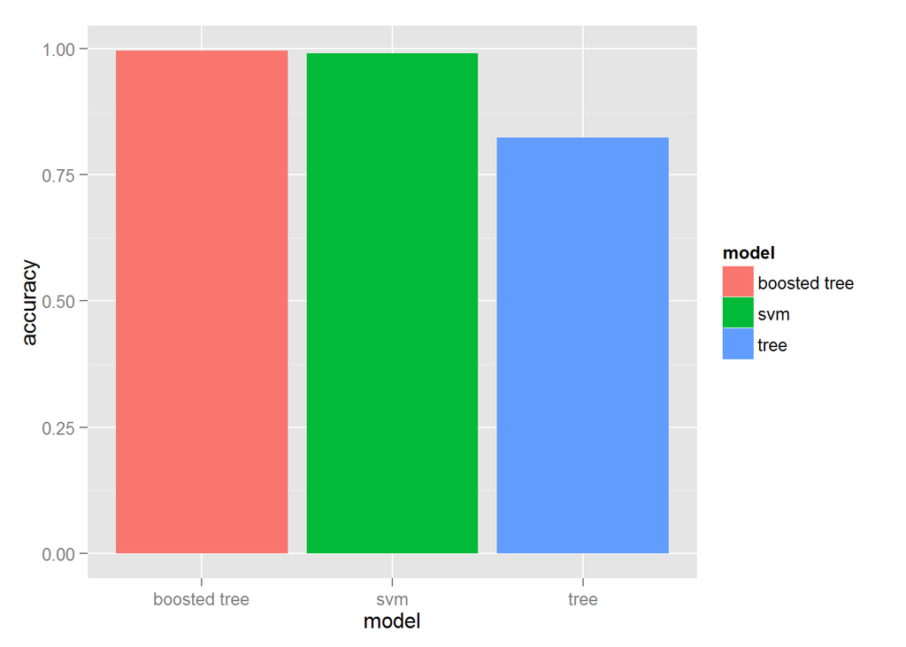

```r
overallAcc <- data.frame(accuracy = c(resultsValidation_tree$overall[1], resultsValidation_gbm$overall[1],resultsValidation_svm$overall[1]), model = c("tree","boosted tree", "svm"))

ggplot(overallAcc, aes(x = model, y = accuracy, fill = model)) + geom_bar(stat = "identity")
```

It can be concluded that boosted tree and SVM have very high classification accuracy (99%) on the unseen data, while the simple decision tree has accuracy about 82%.